# Coffee Menus Across Auckland

## Welcome!

Welcome to this Data Story! In this report we will be exploring data from 40 different coffee menus from various cafes, eateries and bakeries across Auckland. The data that was recorded in our investigation contained just over 3000 cells! That’s a lot of data!

## Coffee Prices and Coffee Types

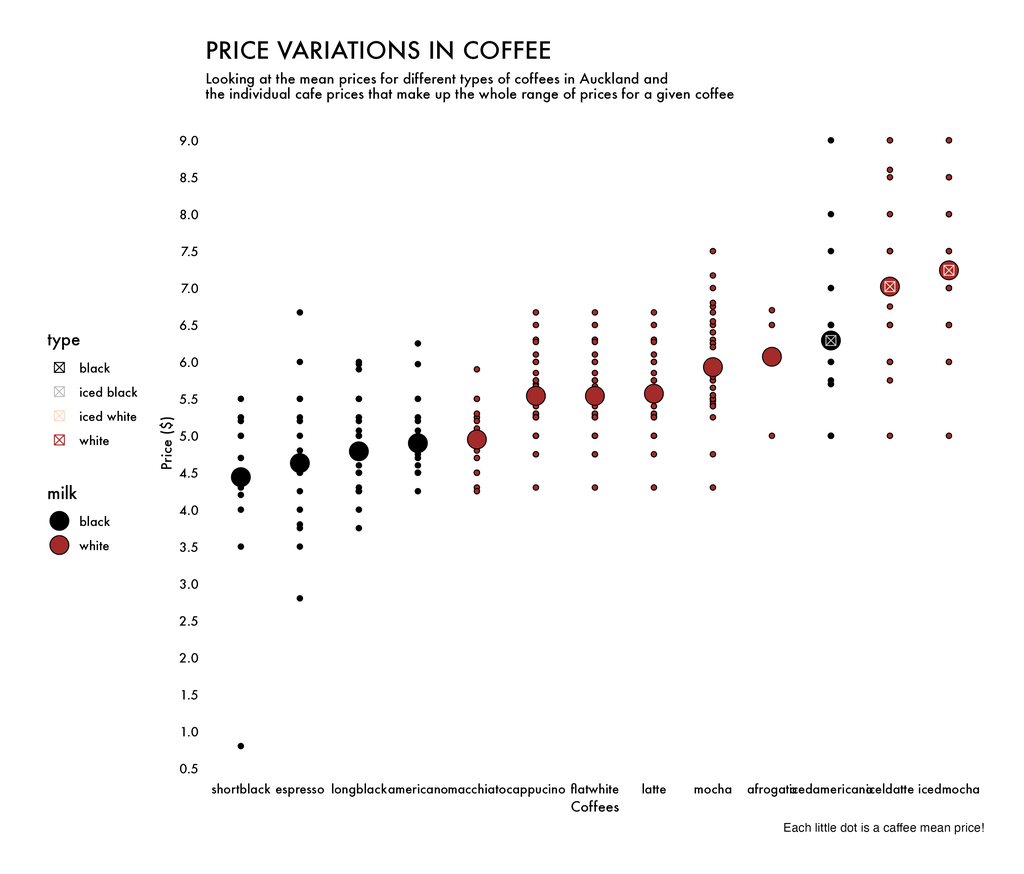

We’re kicking off with probably the most straightforward question you could ask. Prices! How expensive is coffee? How do they vary? In this plot we can see the mean prices of each different kind of coffee (that we tracked and had data on). The first thing that sticks out is there seems to be 3 tiers. Black coffee being the cheapest, no milk just coffee, that’s what we’d expect. Then there’s white coffee, (coffee with milk) and that’s its own band in the middle. But the third tier is iced coffee! We can see that the 3 iced coffees are also the 3 most expensive coffeee types. Even the iced americano is move expensive (on average) than hot white coffees. The reason why that is that iced coffee often requires extra equipment, ice storage etc so its not as cheap to make for cafes as you might think!

It’s also important to stress “on average”, while the big dots are the mean price overall for the coffee, each little dot is an individual mean price from a cafe (a mean of all their prices across sizes if you’re asking). Examining these little dots we can see that each coffee type has a very broad price range. You can get a short black for $5.50 at one place, but you could also get an iced mocha for just $5 at another place!

## COFFEE…Relationships?

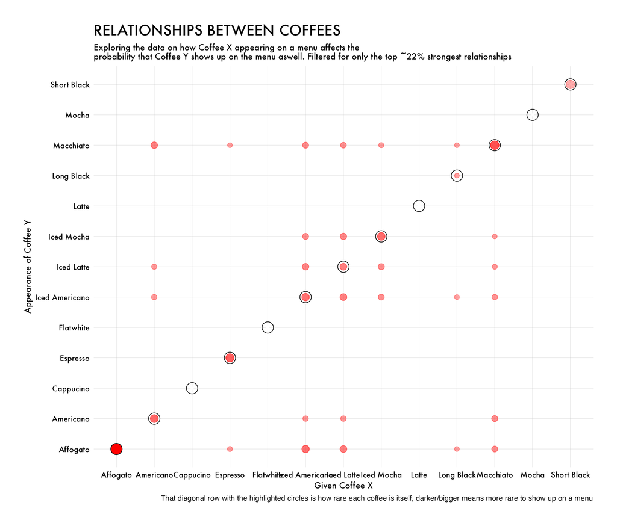

A dotplot illustrating the relationships between different coffee types

Looks confusing, I know. Let me explain how to read this graph, so look at the macchiato column on the bottom right, see how it has a few red dots? That means when a macchiato appears on a menu the chance of the corresponding coffee also appearing increases. Ok so that’s interesting right? If there’s a macchiato on the menu there’s a good chance it’s a pretty broad menu. We can see in the middle that 3x3 grid, those are the three ice coffee types; so they very often appear together as we might expect. As for that diagonal line through the graph, thats when a coffee type is “matched” with itself, the way to read the dot is that bigger/redder means rarer coffee and vice versa. So we can see that affogato is a very rare coffee to appear on menus whereas Cappucinos, Flatwhites, Mochas and Lattes are almost guaranteed to show up.

## A Plot that’s a Table?

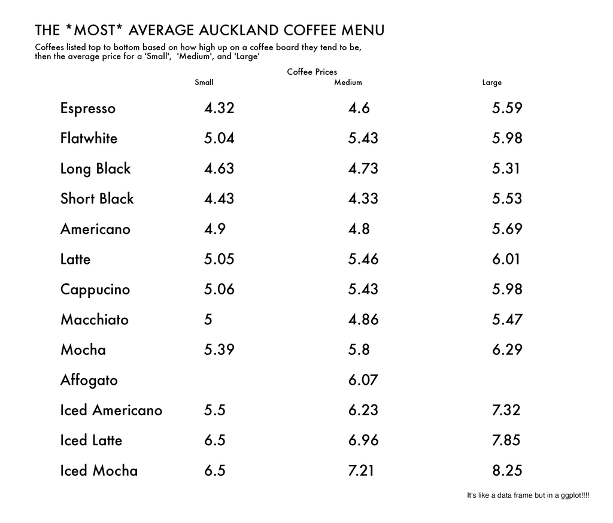

So coffee menus are basically tabular data, we’ve done a bunch of analysis on our tabular data and now we can use ggplot to create our own coffee menu based on our data. The order from coffees top to bottom is based on how high up the menu these coffees tend to be on average. Then each price is the average price at that size as you’d expect. However for some values small is a bit larger than medium (it shouldn’t be) but that’s because of how we’ve recorded data. When only one price was listed it was a medium, this can create weird situations with our data. Maybe more manipulation and mutation next time!

Also the colour scheme is based on the most popular cafe menu scheme colours (black on white, not all that interesting)

## Some Data on my Recording Efforts!

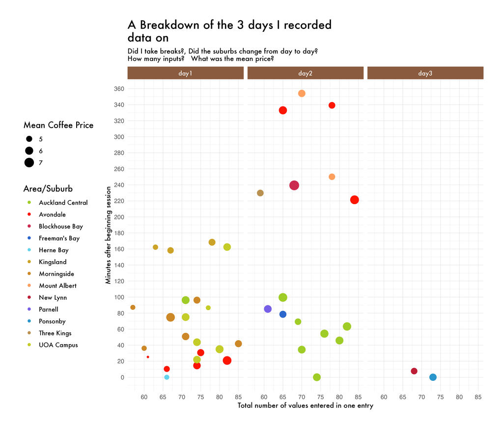

So for Project 2 we were supposed to do the recordings over time, but as is my style I did it all last minute! The day1 graph is my recordings from Project2, day2 and day3 are the days I recorded extra data for this project. I’ve given a lot of labels so it should be fairly straight forward to read. Mean Coffee price is the mean price of all coffees from that menu I recorded, Then “Total Number of Values” is how many non null values I inputted into each entry (around 70 on average). Colour is the area/suburb, you can see that my suburb selection changed from Project 2 to Project 4. That’s because on Project 2 I actually went on a bit of marathon going to cafes and taking photos of their menus. This time I just sourced cafe menus in Auckland from google maps (that were recent enough to use).

My favourite part of this graph is that you can clearly see when I decided to take a break from all that tedious data entry.

## Ugly Ducking

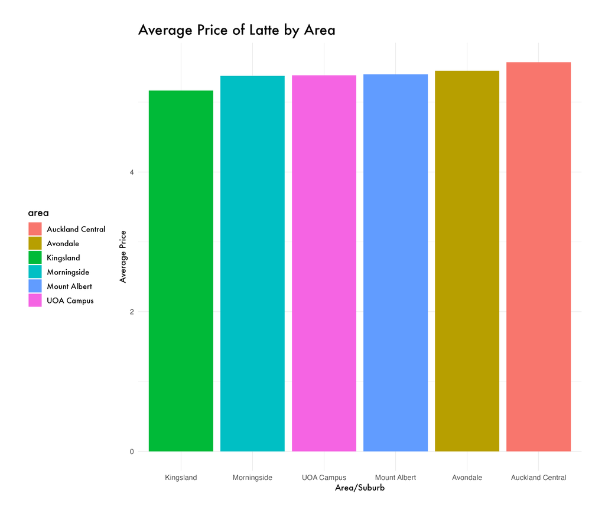

Mediocre Graph

Not much to say about this graph, other than it was made with functions we were required to use! So I’m glad I checked that box! Most of my other data manipulation and graphs requried out of the box thinking because my data was very complex.